# 데이터 과학 – 기초 통계

# 3 데이터 정규분포 근사

[Normal Distribution Project - Liam Larsen](https://www.kaggle.com/kingburrito666/normal-distribution-project-liam-larsen/notebook) 웹사이트에서 컴퓨터 가격데이터를 가져와서 정규성 검정부터 시작해보자.

```r
computer_df <- read_csv("data/Computers.csv")

DT::datatable(computer_df)
```

|  | X1 | price | speed | hd | ram | screen | cd | multi | premium | ads | trend |
| --- | --- | --- | --- | --- | --- | --- | --- | --- | --- | --- | --- |
| 1 | 1 | 1499 | 25 | 80 | 4 | 14 | no | no | yes | 94 | 1 |
| 2 | 2 | 1795 | 33 | 85 | 2 | 14 | no | no | yes | 94 | 1 |
| 3 | 3 | 1595 | 25 | 170 | 4 | 15 | no | no | yes | 94 | 1 |
| 4 | 4 | 1849 | 25 | 170 | 8 | 14 | no | no | no | 94 | 1 |
| 5 | 5 | 3295 | 33 | 340 | 16 | 14 | no | no | yes | 94 | 1 |
| 6 | 6 | 3695 | 66 | 340 | 16 | 14 | no | no | yes | 94 | 1 |
| 7 | 7 | 1720 | 25 | 170 | 4 | 14 | yes | no | yes | 94 | 1 |
| 8 | 8 | 1995 | 50 | 85 | 2 | 14 | no | no | yes | 94 | 1 |
| 9 | 9 | 2225 | 50 | 210 | 8 | 14 | no | no | yes | 94 | 1 |
| 10 | 10 | 2575 | 50 | 210 | 4 | 15 | no | no | yes | 94 | 1 |

[output cut: 6249 more lines]

## 3.1 정규분포 검정

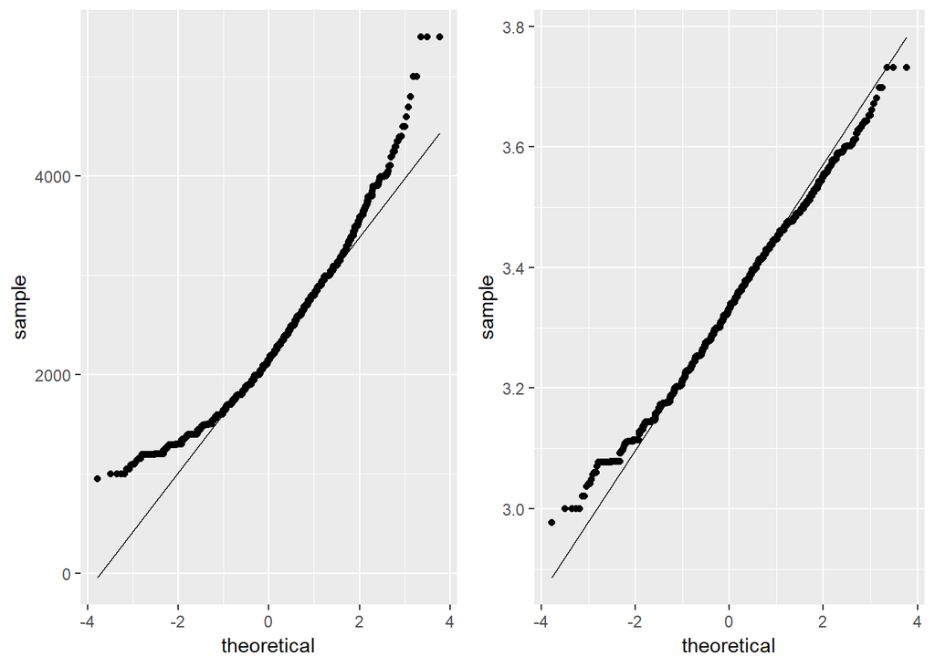

```r
orig_price_g <- ggplot(computer_df, aes(sample=price)) +
  stat_qq() +
  stat_qq_line()

log_price_g <- ggplot(computer_df, aes(sample=log10(price))) +
  stat_qq() +
  stat_qq_line()

cowplot::plot_grid(orig_price_g, log_price_g)
```

`MVN` 팩키지의 `univariateTest` 인자에 Shapiro-Wilk (“SW”), Cramer-von Mises (“CVM”), Lilliefors (“Lillie”), Shapiro-Francia (“SF”), Anderson-Darling (“AD”)을 선택하여 단변량 변수에 대한 정규성을 검정할 수 있다.

```r
library(MVN)

mvn(computer_df$price, univariateTest = "AD")
```

```
$multivariateNormality
[1] "No MVN result. Number of variables is less than 2 "

$univariateNormality
              Test Variable Statistic p value Normality
A Anderson-Darling variable  38.14916 3.7e-24        NO

$Descriptives
            n     Mean Std.Dev Median Min  Max 25th 75th      Skew
variable 6259 2219.577 580.804   2144 949 5399 1794 2595 0.7113836
          Kurtosis
variable 0.7276838
```

```r
mvn(log10(computer_df$price), univariateTest = "AD", univariatePlot = "qq")
```

[output not shown]

```
$multivariateNormality
[1] "No MVN result. Number of variables is less than 2 "

$univariateNormality
              Test Variable Statistic      p value Normality
A Anderson-Darling variable   6.91545 6.311279e-17        NO

$Descriptives
            n     Mean   Std.Dev   Median      Min      Max     25th
variable 6259 3.331807 0.1120526 3.331225 2.977266 3.732313 3.253822
             75th       Skew   Kurtosis
variable 3.414137 0.03121979 -0.3811838
```

## 3.2 정규분포 근사

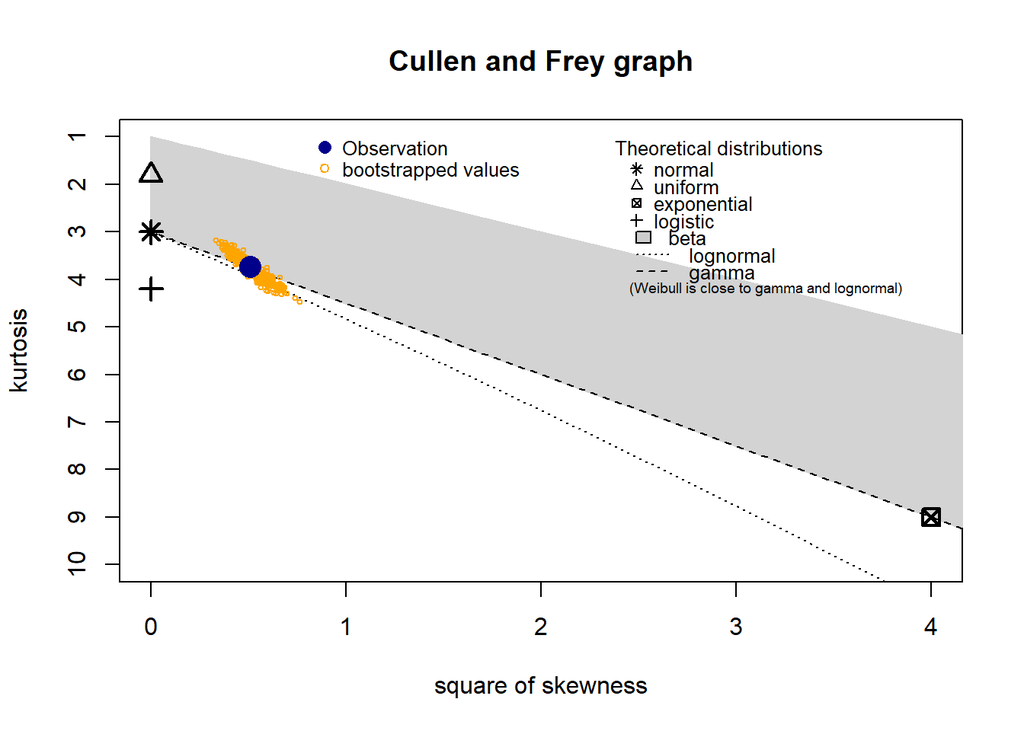

```
summary statistics
------
min:  949   max:  5399
median:  2144
mean:  2219.577
estimated sd:  580.804
estimated skewness:  0.7117247
estimated kurtosis:  3.730417
```

```r
library(fitdistrplus)
descdist(computer_df$price, discrete=FALSE, boot=500)
```

```r
# normal_fit <- fitdistr(computer_df$price, densfun="normal")
```